# Public Data

2024/01/24

## Setup

Install a package `countrycode` first.

```r
library(tidyverse)
library(WDI)
library(readxl)
library(countrycode)
```

## World Inequality Database

https://wid.world

### World Inequality Report 2022

- World Inequality Report 2022: https://wir2022.wid.world
- Methodology [[Link](https://wir2022.wid.world/methodology/)]

*Since Excel files are binary file, you need to add mode = “wb”, web binary.*

```r
url_summary <- "https://wir2022.wid.world/www-site/uploads/2022/03/WIR2022TablesFigures-Summary.xlsx"
download.file(url = url_summary, destfile = "data/WIR2022s.xlsx", mode = "wb")
```

```r
library(readxl) # readxl is a part of tidyverse but not a core package
```

```r
excel_sheets("data/WIR2022s.xlsx")
```

```
 [1] "Index"     "F1"        "F2"        "F3"        "F4"        "F5."       "F6"
 [8] "F7"        "F8"        "F9"        "F10"       "F11"       "F12"       "F13"
[15] "F14"       "F15"       "T1"        "data-F1"   "data-F2"   "data-F3"   "data-F4"
[22] "data-F5"   "data-F6"   "data-F7"   "data-F8"   "data-F9"   "data-F10"  "data-F11"
[29] "data-F12"  "data-F13." "data-F14." "data-F15"
```

```r
df_wir_f2 <- read_excel("data/WIR2022s.xlsx",
    sheet = "data-F2")
df_wir_f2
```

| year | iso | Bottom 50% | Middle 40% | Top 10% |
| --- | --- | --- | --- | --- |
| 2021 | Europe | 0.1891 | 0.4531 | 0.3578 |
| 2021 | East Asia | 0.1391 | 0.4268 | 0.4341 |
| 2021 | North America | 0.1322 | 0.4105 | 0.4573 |
| 2021 | Russia & Central Asia | 0.1466 | 0.3863 | 0.4671 |
| 2021 | South & South East Asia | 0.1233 | 0.3283 | 0.5484 |
| 2021 | Latin America | 0.1016 | 0.3445 | 0.5539 |
| 2021 | Sub-Saharan Africa | 0.0892 | 0.3537 | 0.5571 |
| 2021 | MENA | 0.0900 | 0.3288 | 0.5812 |

Created a new Excel book with only one sheet, and save it as a CSV UTF-8.

```r
df_wir_f2_2 <- read_csv("data/wir-f2.csv")
df_wir_f2_2
```

| year | iso | Bottom 50% | Middle 40% | Top 10% |
| --- | --- | --- | --- | --- |
| 2021 | Europe | 19% | 45% | 36% |
| 2021 | East Asia | 14% | 43% | 43% |
| 2021 | North America | 13% | 41% | 46% |
| 2021 | Russia & Central Asia | 15% | 39% | 47% |
| 2021 | South & South East Asia | 12% | 33% | 55% |
| 2021 | Latin America | 10% | 34% | 55% |
| 2021 | Sub-Saharan Africa | 9% | 35% | 56% |
| 2021 | MENA | 9% | 33% | 58% |

```r
df_wir_f2_2 |> identical(df_wir_f2)
```

```
[1] FALSE
```

```r
df_wir_f2_3 <- read_delim(clipboard())
df_wir_f2_3
```

[output not shown]

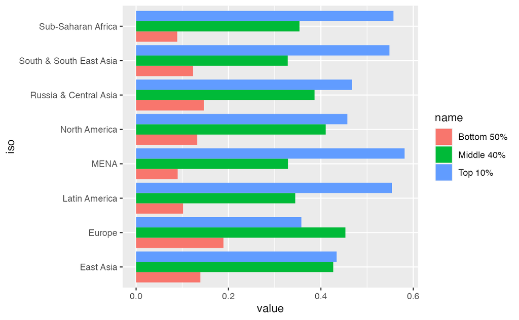

```r
df_wir_f2 |> pivot_longer(3:5) |>
  ggplot(aes(iso, value, fill = name)) + geom_col(position = "dodge") + coord_flip()
```

See: https://ds-sl.github.io/data-analysis/wir2022.nb.html

### To share data with someone else.

```r
df_wir_dput <- dput(df_wir_f2)
```

```
structure(list(year = c(2021, 2021, 2021, 2021, 2021, 2021, 2021,
2021), iso = c("Europe", "East Asia", "North America", "Russia & Central Asia",
"South & South East Asia", "Latin America", "Sub-Saharan Africa",
"MENA"), `Bottom 50%` = c(0.1891, 0.1391, 0.1322, 0.1466, 0.1233,
0.1016, 0.0892, 0.09), `Middle 40%` = c(0.4531, 0.4268, 0.4105,
0.3863, 0.3283, 0.3445, 0.3537, 0.3288), `Top 10%` = c(0.3578,
0.4341, 0.4573, 0.4671, 0.5484, 0.5539, 0.5571, 0.5812)), class = c("tbl_df",
"tbl", "data.frame"), row.names = c(NA, -8L))
```

```r
df_wir_dput
```

| year | iso | Bottom 50% | Middle 40% | Top 10% |
| --- | --- | --- | --- | --- |
| 2021 | Europe | 0.1891 | 0.4531 | 0.3578 |
| 2021 | East Asia | 0.1391 | 0.4268 | 0.4341 |
| 2021 | North America | 0.1322 | 0.4105 | 0.4573 |
| 2021 | Russia & Central Asia | 0.1466 | 0.3863 | 0.4671 |
| 2021 | South & South East Asia | 0.1233 | 0.3283 | 0.5484 |
| 2021 | Latin America | 0.1016 | 0.3445 | 0.5539 |
| 2021 | Sub-Saharan Africa | 0.0892 | 0.3537 | 0.5571 |
| 2021 | MENA | 0.0900 | 0.3288 | 0.5812 |

```r
df_wir_f2_3 <- df_wir_dput
df_wir_f2_3 |> identical(df_wir_f2)
```

```
[1] TRUE
```

## UNdata - a world of information

https://data.un.org/

Popular statistical tables

Explorer - datamarts: http://data.un.org/Explorer.aspx

- Datasets, Sources, Topics

### Popular statistical tables

Copy the link of International Migrants and Refugees

```r
un_migrants_url <- "https://data.un.org/_Docs/SYB/CSV/SYB66_327_202310_International%20Migrants%20and%20Refugees.csv"
download.file(un_migrants_url, destfile = "data/migrants.csv")
```

```r
df_un_migrants <- read_csv("data/migrants.csv")
df_un_migrants
```

| T04 | International migrants and refugees | ...3 | ...4 | ...5 | ...6 | ...7 |
| --- | --- | --- | --- | --- | --- | --- |
| Region/Country/Area | NA | Year | Series | Value | Footnotes | Source |
| 1 | Total, all countries or areas | 2005 | International migrant stock: Both sexes (number) | 191,446,828 | NA | United Nations Population Division, New York, International migrant stock: The 2020 Revision, last accessed January 2022. |
| 1 | Total, all countries or areas | 2005 | International migrant stock: Both sexes (% total population) | 2.9 | NA | United Nations Population Division, New York, International migrant stock: The 2020 Revision, last accessed January 2022. |
| 1 | Total, all countries or areas | 2005 | International migrant stock: Male (% total Population) | 3.0 | NA | United Nations Population Division, New York, International migrant stock: The 2020 Revision, last accessed January 2022. |
| 1 | Total, all countries or areas | 2005 | International migrant stock: Female (% total Population) | 2.9 | NA | United Nations Population Division, New York, International migrant stock: The 2020 Revision, last accessed January 2022. |
| 1 | Total, all countries or areas | 2010 | International migrant stock: Both sexes (number) | 220,983,187 | NA | United Nations Population Division, New York, International migrant stock: The 2020 Revision, last accessed January 2022. |
| 1 | Total, all countries or areas | 2010 | International migrant stock: Both sexes (% total population) | 3.2 | NA | United Nations Population Division, New York, International migrant stock: The 2020 Revision, last accessed January 2022. |
| 1 | Total, all countries or areas | 2010 | International migrant stock: Male (% total Population) | 3.2 | NA | United Nations Population Division, New York, International migrant stock: The 2020 Revision, last accessed January 2022. |
| 1 | Total, all countries or areas | 2010 | International migrant stock: Female (% total Population) | 3.1 | NA | United Nations Population Division, New York, International migrant stock: The 2020 Revision, last accessed January 2022. |
| 1 | Total, all countries or areas | 2015 | International migrant stock: Both sexes (number) | 247,958,644 | NA | United Nations Population Division, New York, International migrant stock: The 2020 Revision, last accessed January 2022. |

[output cut: 990 more lines]

```r
df_un_migrants <- read_csv("data/migrants.csv", skip=1)
df_un_migrants
```

| Region/Country/Area | ...2 | Year | Series | Value | Footnotes | Source |
| --- | --- | --- | --- | --- | --- | --- |
| 1 | Total, all countries or areas | 2005 | International migrant stock: Both sexes (number) | 191446828.0 | NA | United Nations Population Division, New York, International migrant stock: The 2020 Revision, last accessed January 2022. |
| 1 | Total, all countries or areas | 2005 | International migrant stock: Both sexes (% total population) | 2.9 | NA | United Nations Population Division, New York, International migrant stock: The 2020 Revision, last accessed January 2022. |
| 1 | Total, all countries or areas | 2005 | International migrant stock: Male (% total Population) | 3.0 | NA | United Nations Population Division, New York, International migrant stock: The 2020 Revision, last accessed January 2022. |
| 1 | Total, all countries or areas | 2005 | International migrant stock: Female (% total Population) | 2.9 | NA | United Nations Population Division, New York, International migrant stock: The 2020 Revision, last accessed January 2022. |
| 1 | Total, all countries or areas | 2010 | International migrant stock: Both sexes (number) | 220983187.0 | NA | United Nations Population Division, New York, International migrant stock: The 2020 Revision, last accessed January 2022. |
| 1 | Total, all countries or areas | 2010 | International migrant stock: Both sexes (% total population) | 3.2 | NA | United Nations Population Division, New York, International migrant stock: The 2020 Revision, last accessed January 2022. |
| 1 | Total, all countries or areas | 2010 | International migrant stock: Male (% total Population) | 3.2 | NA | United Nations Population Division, New York, International migrant stock: The 2020 Revision, last accessed January 2022. |
| 1 | Total, all countries or areas | 2010 | International migrant stock: Female (% total Population) | 3.1 | NA | United Nations Population Division, New York, International migrant stock: The 2020 Revision, last accessed January 2022. |
| 1 | Total, all countries or areas | 2015 | International migrant stock: Both sexes (number) | 247958644.0 | NA | United Nations Population Division, New York, International migrant stock: The 2020 Revision, last accessed January 2022. |
| 1 | Total, all countries or areas | 2015 | International migrant stock: Both sexes (% total population) | 3.4 | NA | United Nations Population Division, New York, International migrant stock: The 2020 Revision, last accessed January 2022. |

[output cut: 990 more lines]

### Explorer - datamarts

Environment Statistics Database>Water>Internal flow [[Link](http://data.un.org/Data.aspx?d=ENV&f=variableID:5&c=2,3,4,5&s=countryName:asc,yr:desc&v=1)]

*Select columns to add Table ID and Country and Area Code of UN, and download ‘Comma’ a CSV.*

```r
df_un_water <- read_csv("data/UNdata_Export_20240124_010609671.csv")
df_un_water
```

| Table ID | Country or Area Code | Country or Area | Year | Value | Value Footnotes | Unit |
| --- | --- | --- | --- | --- | --- | --- |
| 5 | 8 | Albania | 2017 | 18368.0 | 1 | million cubic metres |
| 5 | 8 | Albania | 2016 | 21846.0 | 1 | million cubic metres |
| 5 | 8 | Albania | 2015 | 19300.0 | 1 | million cubic metres |
| 5 | 8 | Albania | 2014 | 20445.0 | 1 | million cubic metres |
| 5 | 8 | Albania | 2013 | 17451.0 | 1 | million cubic metres |
| 5 | 20 | Andorra | 2019 | 366.6 | NA | million cubic metres |
| 5 | 20 | Andorra | 2018 | 339.0 | NA | million cubic metres |
| 5 | 20 | Andorra | 2017 | 283.8 | NA | million cubic metres |
| 5 | 20 | Andorra | 2016 | 300.9 | NA | million cubic metres |
| 5 | 20 | Andorra | 2015 | 251.0 | NA | million cubic metres |

[output cut: 990 more lines]

### UN Migrants Data

```r
url_un_migrants <- "https://data.un.org/_Docs/SYB/CSV/SYB66_327_202310_International%20Migrants%20and%20Refugees.csv"
```

*Since the url is given, a CSV file can be read directly using `read_csv`.*

```r
df_un_migrants <- read_csv(url_un_migrants, skip = 1)
df_un_migrants
```

| Region/Country/Area | ...2 | Year | Series | Value | Footnotes | Source |
| --- | --- | --- | --- | --- | --- | --- |
| 1 | Total, all countries or areas | 2005 | International migrant stock: Both sexes (number) | 191446828.0 | NA | United Nations Population Division, New York, International migrant stock: The 2020 Revision, last accessed January 2022. |
| 1 | Total, all countries or areas | 2005 | International migrant stock: Both sexes (% total population) | 2.9 | NA | United Nations Population Division, New York, International migrant stock: The 2020 Revision, last accessed January 2022. |
| 1 | Total, all countries or areas | 2005 | International migrant stock: Male (% total Population) | 3.0 | NA | United Nations Population Division, New York, International migrant stock: The 2020 Revision, last accessed January 2022. |
| 1 | Total, all countries or areas | 2005 | International migrant stock: Female (% total Population) | 2.9 | NA | United Nations Population Division, New York, International migrant stock: The 2020 Revision, last accessed January 2022. |
| 1 | Total, all countries or areas | 2010 | International migrant stock: Both sexes (number) | 220983187.0 | NA | United Nations Population Division, New York, International migrant stock: The 2020 Revision, last accessed January 2022. |
| 1 | Total, all countries or areas | 2010 | International migrant stock: Both sexes (% total population) | 3.2 | NA | United Nations Population Division, New York, International migrant stock: The 2020 Revision, last accessed January 2022. |
| 1 | Total, all countries or areas | 2010 | International migrant stock: Male (% total Population) | 3.2 | NA | United Nations Population Division, New York, International migrant stock: The 2020 Revision, last accessed January 2022. |
| 1 | Total, all countries or areas | 2010 | International migrant stock: Female (% total Population) | 3.1 | NA | United Nations Population Division, New York, International migrant stock: The 2020 Revision, last accessed January 2022. |
| 1 | Total, all countries or areas | 2015 | International migrant stock: Both sexes (number) | 247958644.0 | NA | United Nations Population Division, New York, International migrant stock: The 2020 Revision, last accessed January 2022. |
| 1 | Total, all countries or areas | 2015 | International migrant stock: Both sexes (% total population) | 3.4 | NA | United Nations Population Division, New York, International migrant stock: The 2020 Revision, last accessed January 2022. |

[output cut: 990 more lines]

```r
str(df_un_migrants)
```

```
spc_tbl_ [7,238 × 7] (S3: spec_tbl_df/tbl_df/tbl/data.frame)
 $ Region/Country/Area: num [1:7238] 1 1 1 1 1 1 1 1 1 1 ...
 $ ...2               : chr [1:7238] "Total, all countries or areas" "Total, all countries or areas" "Total, all countries or areas" "Total, all countries or areas" ...
 $ Year               : num [1:7238] 2005 2005 2005 2005 2010 ...
 $ Series             : chr [1:7238] "International migrant stock: Both sexes (number)" "International migrant stock: Both sexes (% total population)" "International migrant stock: Male (% total Population)" "International migrant stock: Female (% total Population)" ...
 $ Value              : num [1:7238] 1.91e+08 2.90 3.00 2.90 2.21e+08 ...
 $ Footnotes          : chr [1:7238] NA NA NA NA ...
 $ Source             : chr [1:7238] "United Nations Population Division, New York, International migrant stock: The 2020 Revision, last accessed January 2022." "United Nations Population Division, New York, International migrant stock: The 2020 Revision, last accessed January 2022." "United Nations…
 - attr(*, "spec")=
  .. cols(
  ..   `Region/Country/Area` = col_double(),
  ..   ...2 = col_character(),
  ..   Year = col_double(),
  ..   Series = col_character(),
  ..   Value = col_number(),
  ..   Footnotes = col_character(),
  ..   Source = col_character()
  .. )
 - attr(*, "problems")=<externalptr>
```

```r
df_un_migrants |> summary()
```

```
 Region/Country/Area     ...2                Year         Series
 Min.   :  1.0       Length:7238        Min.   :2005   Length:7238
 1st Qu.:178.0       Class :character   1st Qu.:2010   Class :character
 Median :404.0       Mode  :character   Median :2015   Mode  :character
 Mean   :407.1                          Mean   :2014
 3rd Qu.:630.0                          3rd Qu.:2020
 Max.   :894.0                          Max.   :2022
     Value            Footnotes            Source
 Min.   :        0   Length:7238        Length:7238
 1st Qu.:        5   Class :character   Class :character
 Median :      154   Mode  :character   Mode  :character
 Mean   :   731059
 3rd Qu.:    31096
 Max.   :280598105
```

```r
df_un_migrants |> select(Year,Series) |> lapply(unique)
```

```
$Year
 [1] 2005 2010 2015 2020 2022 2019 2018 2016 2021 2017

$Series
[1] "International migrant stock: Both sexes (number)"
[2] "International migrant stock: Both sexes (% total population)"
[3] "International migrant stock: Male (% total Population)"
[4] "International migrant stock: Female (% total Population)"
[5] "Total refugees and people in refugee-like situations (number)"
[6] "Asylum seekers, including pending cases (number)"
[7] "Other of concern to UNHCR (number)"
[8] "Total population of concern to UNHCR (number)"
```

```r
df_un_migrants |> distinct(`Region/Country/Area`, ...2)
```

[output not shown]

```r
library(countrycode)
df_un_migrants %>% mutate(iso2c_un = countrycode(`Region/Country/Area`, "un", "iso2c"), .after = ...2)
```

| Region/Country/Area | ...2 | iso2c_un | Year | Series | Value | Footnotes | Source |
| --- | --- | --- | --- | --- | --- | --- | --- |
| 1 | Total, all countries or areas | NA | 2005 | International migrant stock: Both sexes (number) | 191446828.0 | NA | United Nations Population Division, New York, International migrant stock: The 2020 Revision, last accessed January 2022. |
| 1 | Total, all countries or areas | NA | 2005 | International migrant stock: Both sexes (% total population) | 2.9 | NA | United Nations Population Division, New York, International migrant stock: The 2020 Revision, last accessed January 2022. |
| 1 | Total, all countries or areas | NA | 2005 | International migrant stock: Male (% total Population) | 3.0 | NA | United Nations Population Division, New York, International migrant stock: The 2020 Revision, last accessed January 2022. |
| 1 | Total, all countries or areas | NA | 2005 | International migrant stock: Female (% total Population) | 2.9 | NA | United Nations Population Division, New York, International migrant stock: The 2020 Revision, last accessed January 2022. |
| 1 | Total, all countries or areas | NA | 2010 | International migrant stock: Both sexes (number) | 220983187.0 | NA | United Nations Population Division, New York, International migrant stock: The 2020 Revision, last accessed January 2022. |
| 1 | Total, all countries or areas | NA | 2010 | International migrant stock: Both sexes (% total population) | 3.2 | NA | United Nations Population Division, New York, International migrant stock: The 2020 Revision, last accessed January 2022. |
| 1 | Total, all countries or areas | NA | 2010 | International migrant stock: Male (% total Population) | 3.2 | NA | United Nations Population Division, New York, International migrant stock: The 2020 Revision, last accessed January 2022. |
| 1 | Total, all countries or areas | NA | 2010 | International migrant stock: Female (% total Population) | 3.1 | NA | United Nations Population Division, New York, International migrant stock: The 2020 Revision, last accessed January 2022. |
| 1 | Total, all countries or areas | NA | 2015 | International migrant stock: Both sexes (number) | 247958644.0 | NA | United Nations Population Division, New York, International migrant stock: The 2020 Revision, last accessed January 2022. |
| 1 | Total, all countries or areas | NA | 2015 | International migrant stock: Both sexes (% total population) | 3.4 | NA | United Nations Population Division, New York, International migrant stock: The 2020 Revision, last accessed January 2022. |

[output cut: 990 more lines]

```r
df_un_migrants |> mutate(iso2c_un = countrycode(`Region/Country/Area`, "un", "iso2c"), .after = ...2) |> filter(is.na(iso2c_un)) |> distinct(...2)
```

| ...2 |
| --- |
| Total, all countries or areas |
| Africa |
| Northern Africa |
| Sub-Saharan Africa |
| Eastern Africa |
| Middle Africa |
| Southern Africa |
| Western Africa |
| Northern America |
| Latin America & the Caribbean |

[output cut: 22 more lines]

```r
wdicache <- read_rds("data/wdicache.rds")
wdi_country_extra <- wdicache$country |> select(iso2c, region, income, lending)
```

```r
df_un_migrants_ext <- df_un_migrants %>%
  mutate(iso2c_un = countrycode(`Region/Country/Area`, "un", "iso2c"), .after = ...2) |>
  drop_na(iso2c_un) |>
  select(Country = ...2, ISO2C = iso2c_un, Year, Series, Value, Footnotes) |>
  left_join(wdi_country_extra, by = c("ISO2C" = "iso2c"))
df_un_migrants_ext
```

| Country | ISO2C | Year | Series | Value | Footnotes | region | income | lending |
| --- | --- | --- | --- | --- | --- | --- | --- | --- |
| Afghanistan | AF | 2005 | International migrant stock: Both sexes (number) | 87314.0 | Including refugees. | South Asia | Low income | IDA |
| Afghanistan | AF | 2005 | International migrant stock: Both sexes (% total population) | 0.3 | Including refugees. | South Asia | Low income | IDA |
| Afghanistan | AF | 2005 | International migrant stock: Male (% total Population) | 0.4 | Including refugees. | South Asia | Low income | IDA |
| Afghanistan | AF | 2005 | International migrant stock: Female (% total Population) | 0.3 | Including refugees. | South Asia | Low income | IDA |
| Afghanistan | AF | 2005 | Total refugees and people in refugee-like situations (number) | 32.0 | NA | South Asia | Low income | IDA |
| Afghanistan | AF | 2005 | Asylum seekers, including pending cases (number) | 14.0 | NA | South Asia | Low income | IDA |
| Afghanistan | AF | 2005 | Other of concern to UNHCR (number) | 159551.0 | NA | South Asia | Low income | IDA |
| Afghanistan | AF | 2005 | Total population of concern to UNHCR (number) | 159597.0 | NA | South Asia | Low income | IDA |
| Afghanistan | AF | 2010 | International migrant stock: Both sexes (number) | 102276.0 | Including refugees. | South Asia | Low income | IDA |
| Afghanistan | AF | 2010 | International migrant stock: Both sexes (% total population) | 0.4 | Including refugees. | South Asia | Low income | IDA |

[output cut: 990 more lines]

```r
df_un_migrants_ext$Series |> unique()
```

```
[1] "International migrant stock: Both sexes (number)"
[2] "International migrant stock: Both sexes (% total population)"
[3] "International migrant stock: Male (% total Population)"
[4] "International migrant stock: Female (% total Population)"
[5] "Total refugees and people in refugee-like situations (number)"
[6] "Asylum seekers, including pending cases (number)"
[7] "Other of concern to UNHCR (number)"
[8] "Total population of concern to UNHCR (number)"
```

```r
df_un_migrants_ext_rev <- df_un_migrants_ext |> mutate(Ser = case_when(
  Series == "International migrant stock: Both sexes (number)" ~ "migrant",
  Series == "International migrant stock: Both sexes (% total population)" ~ "migrant_percent",
  Series == "International migrant stock: Male (% total Population)" ~ "migrant_male",
  Series == "International migrant stock: Female (% total Population)" ~ "migrant_female",
  Series == "Total refugees and people in refugee-like situations (number)" ~ "refugee",
  Series == "Asylum seekers, including pending cases (number)" ~ "asylum",
  Series == "Other of concern to UNHCR (number)"  ~ "other",
  Series == "Total population of concern to UNHCR (number)" ~ "concern",
  TRUE ~ Series), .before = Series)
```

```r
df_un_migrants_ext_rev
```

| Country | ISO2C | Year | Ser | Series | Value | Footnotes | region | income | lending |
| --- | --- | --- | --- | --- | --- | --- | --- | --- | --- |
| Afghanistan | AF | 2005 | migrant | International migrant stock: Both sexes (number) | 87314.0 | Including refugees. | South Asia | Low income | IDA |
| Afghanistan | AF | 2005 | migrant_percent | International migrant stock: Both sexes (% total population) | 0.3 | Including refugees. | South Asia | Low income | IDA |
| Afghanistan | AF | 2005 | migrant_male | International migrant stock: Male (% total Population) | 0.4 | Including refugees. | South Asia | Low income | IDA |
| Afghanistan | AF | 2005 | migrant_female | International migrant stock: Female (% total Population) | 0.3 | Including refugees. | South Asia | Low income | IDA |
| Afghanistan | AF | 2005 | refugee | Total refugees and people in refugee-like situations (number) | 32.0 | NA | South Asia | Low income | IDA |
| Afghanistan | AF | 2005 | asylum | Asylum seekers, including pending cases (number) | 14.0 | NA | South Asia | Low income | IDA |
| Afghanistan | AF | 2005 | other | Other of concern to UNHCR (number) | 159551.0 | NA | South Asia | Low income | IDA |
| Afghanistan | AF | 2005 | concern | Total population of concern to UNHCR (number) | 159597.0 | NA | South Asia | Low income | IDA |
| Afghanistan | AF | 2010 | migrant | International migrant stock: Both sexes (number) | 102276.0 | Including refugees. | South Asia | Low income | IDA |
| Afghanistan | AF | 2010 | migrant_percent | International migrant stock: Both sexes (% total population) | 0.4 | Including refugees. | South Asia | Low income | IDA |

[output cut: 990 more lines]

```r
dput(df_un_migrants_ext_rev)
```

## OECD data

https://data.oecd.org/

Database Access: https://data-explorer.oecd.org/

### Expenditure on educational institutions per full-time equivalent student

[Link]

Table in Excel, Filtered data in tableau text (CSV), Unfiltered data in tableau text (CSV) 136.4MB

```r
temp <- read_csv("../../../bigdata/OECD.EDU.IMEP,DSD_EAG_UOE_FIN@DF_UOE_INDIC_FIN_PERSTUD,1.0+all.csv")
temp
```

[output not shown]

```r
library(readxl)
df_oecd_ed <- read_excel("data/OECD.EDU.IMEP,DSD_EAG_UOE_FIN@DF_UOE_INDIC_FIN_PERSTUD,1.0,filtered,2024-01-24 10-22-31.xlsx")
```

```r
df_oecd_ed
```

| Expenditure on educational institutions per full-time equivalent student | ...2 | ...3 | ...4 | ...5 | ...6 | ...7 | ...8 | ...9 | ...10 | ...11 | ...12 | ...13 |
| --- | --- | --- | --- | --- | --- | --- | --- | --- | --- | --- | --- | --- |
| Measure: Expenditure per full-time equivalent student | NA | NA | NA | NA | NA | NA | NA | NA | NA | NA | NA | NA |
| Destination of expenditure: All educational institutions | NA | NA | NA | NA | NA | NA | NA | NA | NA | NA | NA | NA |
| Type of expenditure: Expenditure for educational institutions | NA | NA | NA | NA | NA | NA | NA | NA | NA | NA | NA | NA |
| Time period: 2020 | NA | NA | NA | NA | NA | NA | NA | NA | NA | NA | NA | NA |
| NA | NA | NA | NA | NA | NA | NA | NA | NA | NA | NA | NA | NA |
| Education level | Education level | Primary to tertiary education | Primary education | Lower secondary education | Upper secondary education | · \nUpper secondary general education | · \nUpper secondary vocational education | Post-secondary non-tertiary education | Tertiary education | · \nShort-cycle tertiary education | · \nBachelor's, Master's and Doctoral or equivalent level | NA |
| Reference area | NA | NA | NA | NA | NA | NA | NA | NA | NA | NA | NA | NA |
| Combined unit of measure: US dollars per student, PPP converted | NA | NA | NA | NA | NA | NA | NA | NA | NA | NA | NA | NA |
| Australia | NA | 15620.15 | 12672.54 | 15713.55 | 14947.44 | 16068.14 | 11999.8 | 10166.79 | 22204.119 | 11980.32 | 24324.74 | NA |
| Austria | NA | 17743.801 | 14029.22 | 17306.811 | 17694.75 | 15101.25 | 19469.25 | 4626.4868 | 21753.461 | 18946.711 | 22250.689 | NA |

[output cut: 103 more lines]

```r
df_oecd_ed <- read_excel("data/OECD.EDU.IMEP,DSD_EAG_UOE_FIN@DF_UOE_INDIC_FIN_PERSTUD,1.0,filtered,2024-01-24 10-22-31.xlsx", skip = 6)
df_oecd_ed
```

| Education level...1 | Education level...2 | Primary to tertiary education | Primary education | Lower secondary education | Upper secondary education | · Upper secondary general education | · Upper secondary vocational education | Post-secondary non-tertiary education | Tertiary education | · Short-cycle tertiary education | · Bachelor's, Master's and Doctoral or equivalent level | ...13 |
| --- | --- | --- | --- | --- | --- | --- | --- | --- | --- | --- | --- | --- |
| Reference area | NA | NA | NA | NA | NA | NA | NA | NA | NA | NA | NA | NA |
| Combined unit of measure: US dollars per student, PPP converted | NA | NA | NA | NA | NA | NA | NA | NA | NA | NA | NA | NA |
| Australia | NA | 15620.15 | 12672.54 | 15713.55 | 14947.44 | 16068.14 | 11999.8 | 10166.79 | 22204.119 | 11980.32 | 24324.74 | NA |
| Austria | NA | 17743.801 | 14029.22 | 17306.811 | 17694.75 | 15101.25 | 19469.25 | 4626.4868 | 21753.461 | 18946.711 | 22250.689 | NA |
| Belgium | NA | 16428.811 | 12813 | 16634.801 | 16543.41 | 15578.6 | 17314.93 | K .. | 22555.439 | 13658.67 | 22916.859 | NA |
| Canada | NA | 15442.98 | 11533.2 | K .. | 14519.74 | K .. | K .. | O .. | 24362.68 | 16632.449 | 28707.02 | NA |
| Chile | NA | 7183.8838 | 5917.4229 | 6153.3481 | 5719.6089 | 5146.854 | 8638.9043 | M .. | 10458.01 | 5296.0068 | 12251.74 | NA |
| Colombia | NA | 4481.4321 | 4363.6118 | 4335.042 | 4356.8389 | K .. | K .. | O .. | 4980.6108 | K .. | K .. | NA |
| Costa Rica | NA | O .. | O .. | O .. | O .. | O .. | O .. | M .. | 15424.3 | K .. | K .. | NA |
| Czechia | NA | 11845.81 | 8466.04 | 12759.65 | 12374.44 | 11313.48 | 12799.22 | 2221.106 | 16237.33 | 31028.301 | 16189.65 | NA |

[output cut: 97 more lines]

```r
colnames(df_oecd_ed)
```

```
 [1] "Education level...1"
 [2] "Education level...2"
 [3] "Primary to tertiary education"
 [4] "Primary education"
 [5] "Lower secondary education"
 [6] "Upper secondary education"
 [7] "· \nUpper secondary general education"
 [8] "· \nUpper secondary vocational education"
 [9] "Post-secondary non-tertiary education"
[10] "Tertiary education"
[11] "· \nShort-cycle tertiary education"
[12] "· \nBachelor's, Master's and Doctoral or equivalent level"
[13] "...13"
```

```r
df_oecd_ed_short <- df_oecd_ed |> select(1,3,4,5,6,9,10) |> drop_na(`Primary education`)
df_oecd_ed_short
```

| Education level...1 | Primary to tertiary education | Primary education | Lower secondary education | Upper secondary education | Post-secondary non-tertiary education | Tertiary education |
| --- | --- | --- | --- | --- | --- | --- |
| Australia | 15620.15 | 12672.54 | 15713.55 | 14947.44 | 10166.79 | 22204.119 |
| Austria | 17743.801 | 14029.22 | 17306.811 | 17694.75 | 4626.4868 | 21753.461 |
| Belgium | 16428.811 | 12813 | 16634.801 | 16543.41 | K .. | 22555.439 |
| Canada | 15442.98 | 11533.2 | K .. | 14519.74 | O .. | 24362.68 |
| Chile | 7183.8838 | 5917.4229 | 6153.3481 | 5719.6089 | M .. | 10458.01 |
| Colombia | 4481.4321 | 4363.6118 | 4335.042 | 4356.8389 | O .. | 4980.6108 |
| Costa Rica | O .. | O .. | O .. | O .. | M .. | 15424.3 |
| Czechia | 11845.81 | 8466.04 | 12759.65 | 12374.44 | 2221.106 | 16237.33 |
| Denmark | 16311.53 | 14272.99 | 17401.6 | 11343.92 | M .. | 23432.01 |
| Estonia | 11087.88 | 10308.8 | 10563.08 | 6583.9268 | 9686.4902 | 17930.48 |

[output cut: 92 more lines]

```r
df_oecd_ed2 <- read_csv("data/OECD.EDU.IMEP,DSD_EAG_UOE_FIN@DF_UOE_INDIC_FIN_PERSTUD,1.0+..ISCED11_1+ISCED11_2+ISCED11_3+ISCED11_4+ISCED11_5+ISCED11_5T8+ISCED11_6T8+ISCED11_1T8._T.INST_EDU.DIR_EXP...csv")
df_oecd_ed2
```

| STRUCTURE | STRUCTURE_ID | STRUCTURE_NAME | ACTION | MEASURE | ...6 | REF_AREA | ...8 | EDUCATION_LEV | ...10 | EXP_SOURCE | ...12 | EXP_DESTINATION | ...14 | EXPENDITURE_TYPE | ...16 | PRICE_BASE | ...18 | UNIT_MEASURE | ...20 | TIME_PERIOD | ...22 | OBS_VALUE | ...24 | OBS_STATUS | ...26 | UNIT_MULT | ...28 | DECIMALS | ...30 | … |
| --- | --- | --- | --- | --- | --- | --- | --- | --- | --- | --- | --- | --- | --- | --- | --- | --- | --- | --- | --- | --- | --- | --- | --- | --- | --- | --- | --- | --- | --- | --- |
| DATAFLOW | OECD.EDU.IMEP:DSD_EAG_UOE_FIN@DF_UOE_INDIC_FIN_PERSTUD(1.0) | NA | I | FIN_PERSTUD | NA | MEX | NA | ISCED11_5 | NA | _T | NA | INST_EDU | NA | DIR_EXP | NA | _Z | NA | PT_B1GQ_POP | NA | 2020 | NA | NA | NA | K | NA | 0 | NA | 0 | NA | … |
| DATAFLOW | OECD.EDU.IMEP:DSD_EAG_UOE_FIN@DF_UOE_INDIC_FIN_PERSTUD(1.0) | NA | I | FIN_PERSTUD | NA | SWE | NA | ISCED11_5T8 | NA | _T | NA | INST_EDU | NA | DIR_EXP | NA | V | NA | USD_PPP_ST | NA | 2020 | NA | 26214.660000 | NA | A | NA | 0 | NA | 0 | NA | … |
| DATAFLOW | OECD.EDU.IMEP:DSD_EAG_UOE_FIN@DF_UOE_INDIC_FIN_PERSTUD(1.0) | NA | I | FIN_PERSTUD | NA | CHL | NA | ISCED11_1 | NA | _T | NA | INST_EDU | NA | DIR_EXP | NA | V | NA | USD_PPP_ST | NA | 2020 | NA | 5917.422900 | NA | A | NA | 0 | NA | 0 | NA | … |
| DATAFLOW | OECD.EDU.IMEP:DSD_EAG_UOE_FIN@DF_UOE_INDIC_FIN_PERSTUD(1.0) | NA | I | FIN_PERSTUD | NA | CAN | NA | ISCED11_1T8 | NA | _T | NA | INST_EDU | NA | DIR_EXP | NA | V | NA | USD_PPP_ST | NA | 2020 | NA | 15442.980000 | NA | A | NA | 0 | NA | 0 | NA | … |
| DATAFLOW | OECD.EDU.IMEP:DSD_EAG_UOE_FIN@DF_UOE_INDIC_FIN_PERSTUD(1.0) | NA | I | FIN_PERSTUD | NA | SVN | NA | ISCED11_2 | NA | _T | NA | INST_EDU | NA | DIR_EXP | NA | V | NA | USD_PPP_ST | NA | 2020 | NA | 11398.460000 | NA | A | NA | 0 | NA | 0 | NA | … |
| DATAFLOW | OECD.EDU.IMEP:DSD_EAG_UOE_FIN@DF_UOE_INDIC_FIN_PERSTUD(1.0) | NA | I | FIN_PERSTUD | NA | SVN | NA | ISCED11_2 | NA | _T | NA | INST_EDU | NA | DIR_EXP | NA | _Z | NA | PT_B1GQ_POP | NA | 2020 | NA | 27.893370 | NA | A | NA | 0 | NA | 0 | NA | … |
| DATAFLOW | OECD.EDU.IMEP:DSD_EAG_UOE_FIN@DF_UOE_INDIC_FIN_PERSTUD(1.0) | NA | I | FIN_PERSTUD | NA | HUN | NA | ISCED11_4 | NA | _T | NA | INST_EDU | NA | DIR_EXP | NA | _Z | NA | PT_B1GQ_POP | NA | 2020 | NA | 30.060690 | NA | A | NA | 0 | NA | 0 | NA | … |
| DATAFLOW | OECD.EDU.IMEP:DSD_EAG_UOE_FIN@DF_UOE_INDIC_FIN_PERSTUD(1.0) | NA | I | FIN_PERSTUD | NA | OECD | NA | ISCED11_6T8 | NA | _T | NA | INST_EDU | NA | DIR_EXP | NA | _Z | NA | PT_B1GQ_POP | NA | 2020 | NA | 41.899680 | NA | A | NA | 0 | NA | 0 | NA | … |
| DATAFLOW | OECD.EDU.IMEP:DSD_EAG_UOE_FIN@DF_UOE_INDIC_FIN_PERSTUD(1.0) | NA | I | FIN_PERSTUD | NA | IND | NA | ISCED11_1 | NA | _T | NA | INST_EDU | NA | DIR_EXP | NA | V | NA | USD_PPP_ST | NA | 2020 | NA | NA | NA | O | NA | 0 | NA | 0 | NA | … |
| DATAFLOW | OECD.EDU.IMEP:DSD_EAG_UOE_FIN@DF_UOE_INDIC_FIN_PERSTUD(1.0) | NA | I | FIN_PERSTUD | NA | SAU | NA | ISCED11_5 | NA | _T | NA | INST_EDU | NA | DIR_EXP | NA | V | NA | USD_PPP_ST | NA | 2020 | NA | NA | NA | O | NA | 0 | NA | 0 | NA | … |

[output cut: 806 more lines]

## Modeling

- searching models: few numbers
- linear regression

```r
cars
```

| speed | dist |
| --- | --- |
| 4 | 2 |
| 4 | 10 |
| 7 | 4 |
| 7 | 22 |
| 8 | 16 |
| 9 | 10 |
| 10 | 18 |
| 10 | 26 |
| 10 | 34 |
| 11 | 17 |

[output cut: 40 more lines]

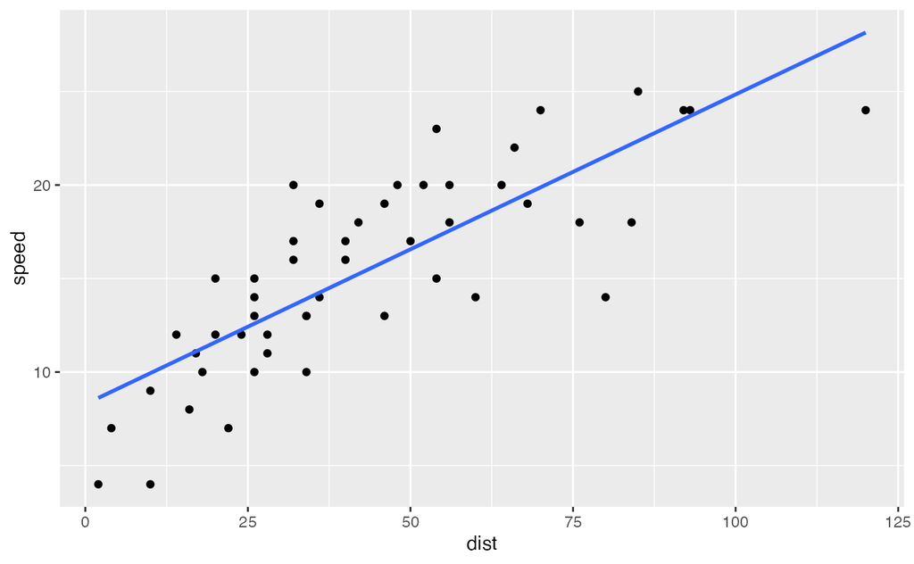

```r
cars |> ggplot(aes(dist, speed)) + geom_point() +
  geom_smooth(formula = 'y ~ x', method = "lm", se=FALSE)
```

```r
cars |> lm(dist ~ speed, data = _) |> summary()
```

```
Call:
lm(formula = dist ~ speed, data = cars)

Residuals:
    Min      1Q  Median      3Q     Max
-29.069  -9.525  -2.272   9.215  43.201

Coefficients:
            Estimate Std. Error t value Pr(>|t|)
(Intercept) -17.5791     6.7584  -2.601   0.0123 *
speed         3.9324     0.4155   9.464 1.49e-12 ***
---
Signif. codes:  0 ‘***’ 0.001 ‘**’ 0.01 ‘*’ 0.05 ‘.’ 0.1 ‘ ’ 1

Residual standard error: 15.38 on 48 degrees of freedom
Multiple R-squared:  0.6511,    Adjusted R-squared:  0.6438
F-statistic: 89.57 on 1 and 48 DF,  p-value: 1.49e-12
```

## References

- Data Analysis for Researchers. [[Link](https://icu-hsuzuki.github.io/da4r/)]
- H. Wickham. *R for Data Science (2e)*. [[Link](https://r4ds.hadley.nz)]・[[O’REILLY](https://www.oreilly.com/library/view/r-for-data/9781492097396/)].
  - Data transformation [[Link](https://r4ds.hadley.nz/data-transform)]
  - Data tidying [[Link](https://r4ds.hadley.nz/data-tidy)]
  - Data import [[Link](https://r4ds.hadley.nz/data-import)]
  - Import [[Link](https://r4ds.hadley.nz/import)]
- Posit Recipes（New edition of Posit Primers）: interactive exercises [[Link](https://posit.cloud/learn/recipes)]
- Cheat Sheet. [[Site Link](https://rstudio.github.io/cheatsheets/)]
  - Data import with the tidyverse [[Link](https://rstudio.github.io/cheatsheets/html/data-import.html)]
  - Data transformation with dplyr [[Link](https://rstudio.github.io/cheatsheets/html/data-transformation.html)]
- dplyr: A Grammar of Data Manipulation [[Link](https://CRAN.R-project.org/package=dplyr)]
  - Two-table verbs [[Link](https://cran.r-project.org/web/packages/dplyr/vignettes/two-table.html)]
- Model Summary
  - r-statistics.co by Selva Prabhakaran:
    - http://r-statistics.co/Linear-Regression.html
  - Meaning Behind Each Section of Summary()
    - https://www.learnbymarketing.com/tutorials/explaining-the-lm-summary-in-r/
- swirl: `install.packages("swirl")` `libray(swirl)`, and `swirl()` after `rm(list=ls())`